# Linear Algebra: an Overview [1]

### Geometry of Vector Norms

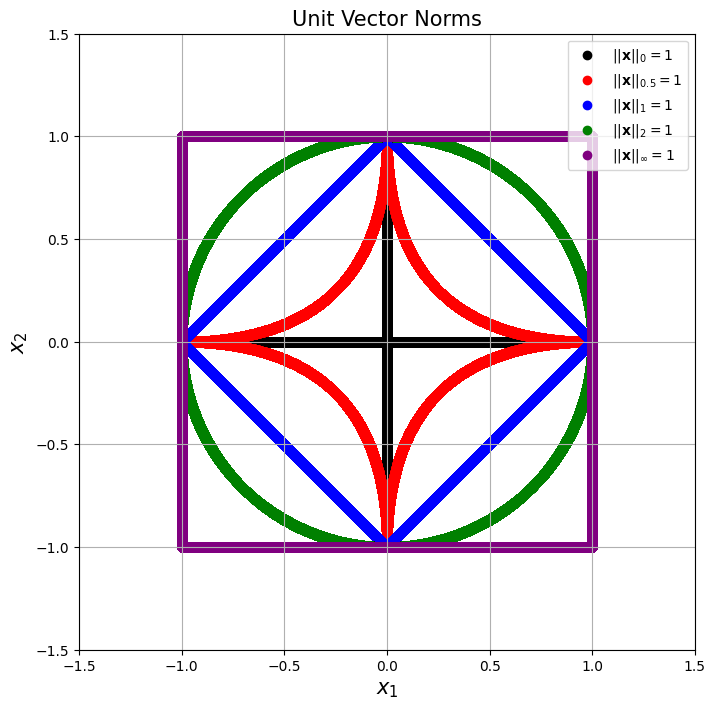

```python
# Generating values for both the axes
x = np.linspace(-1, 1, 2001)
y = np.linspace(-1, 1, 2001)

# Generating the grid and coordinates
X, Y    = np.meshgrid(x, y)
vectors = np.vstack([X.ravel(), Y.ravel()]).T

# Calculate norms
norm_0   = np.linalg.norm(vectors, ord = 0, axis = 1)
norm_05  = np.linalg.norm(vectors, ord = 0.5, axis = 1)
norm_1   = np.linalg.norm(vectors, ord = 1, axis = 1)
norm_2   = np.linalg.norm(vectors, ord = 2, axis = 1)
norm_inf = np.linalg.norm(vectors, ord = np.inf, axis = 1)

# Rescale vectors to have unit norms [except zero norm; it is directly indexed]
vectors_0   = vectors[np.where(norm_0 == 1)]
vectors_05  = vectors[np.where(norm_05 != 0)] / norm_05[norm_05 != 0].reshape(-1, 1)
vectors_1   = vectors[np.where(norm_1 != 0)] / norm_1[norm_1 != 0].reshape(-1, 1)
vectors_2   = vectors[np.where(norm_2 != 0)] / norm_2[norm_2 != 0].reshape(-1, 1)
vectors_inf = vectors[np.where(norm_inf != 0)] / norm_inf[norm_inf != 0].reshape(-1, 1)

# Plotting
plt.figure(figsize = (10, 8))
plt.scatter(vectors_0[:, 0], vectors_0[:, 1], label = r'$||\mathbf{x}||_0 = 1$', c = 'k')
plt.scatter(vectors_05[:, 0], vectors_05[:, 1], label = r'$||\mathbf{x}||_{0.5} = 1$', c = 'red')
plt.scatter(vectors_1[:, 0], vectors_1[:, 1], label = r'$||\mathbf{x}||_1 = 1$', c = 'blue')
plt.scatter(vectors_2[:, 0], vectors_2[:, 1], label = r'$||\mathbf{x}||_2 = 1$', c = 'green')
plt.scatter(vectors_inf[:, 0], vectors_inf[:, 1], label = r'$||\mathbf{x}||_{\infty} = 1$', c = 'purple')
plt.title('Unit Vector Norms', fontsize = 15)
plt.xlabel(r'$x_1$', fontsize = 15)
plt.ylabel(r'$x_2$', fontsize = 15)
plt.legend(loc = 'upper right')
plt.grid(True)
plt.xlim([-1.5, 1.5])
plt.ylim([-1.5, 1.5])

plt.gca().set_aspect('equal', adjustable = 'box') # Set equal aspect ratio to display squares as squares
plt.show()                                        # Show the plot
```

### Norm Balls

This cell may take longer to execute. Note that the $l_{0.5}$ ball is incomplete. Due to memory and time constraints, the arguments of `np.linspace` are designed to produce insufficient points. For more comprehensive visualizations, refer to resources available online [5].

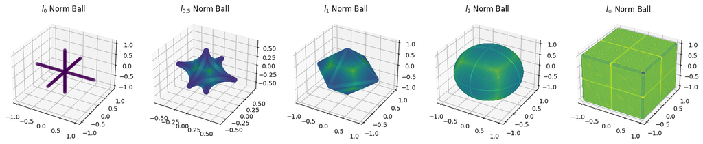

```python
# Generate vectors
x           = np.linspace(-1, 1, 101)
y           = np.linspace(-1, 1, 101)
z           = np.linspace(-1, 1, 101)
X, Y, Z     = np.meshgrid(x, y, z)
vectors     = np.vstack([X.ravel(), Y.ravel(), Z.ravel()]).T
vectors_new = vectors[(vectors != 0).all(axis = 1)]

# Calculate norms
norm_0   = np.linalg.norm(vectors, ord = 0, axis = 1)
norm_05  = np.linalg.norm(vectors_new, ord = 0.5, axis = 1)
norm_1   = np.linalg.norm(vectors_new, ord = 1, axis = 1)
norm_2   = np.linalg.norm(vectors_new, ord = 2, axis = 1)
norm_inf = np.linalg.norm(vectors_new, ord = np.inf, axis = 1)

# Rescale vectors to have unit norms [except zero norm; it is directly indexed]
vectors_0   =  vectors[np.where(norm_0 == 1)]
vectors_05  = vectors_new / norm_05.reshape(-1, 1)
vectors_1   = vectors_new / norm_1.reshape(-1, 1)
vectors_2   = vectors_new / norm_2.reshape(-1, 1)
vectors_inf = vectors_new / norm_inf.reshape(-1, 1)

fig = plt.figure(figsize = (20, 5)) # Plot the figure

# l_0 norm subplot
ax1 = fig.add_subplot(151, projection = '3d')
ax1.scatter(vectors_0[:, 0], vectors_0[:, 1], vectors_0[:, 2],
            c = norm_0[norm_0 == 1], alpha = 0.3)
ax1.set_title('$l_0$ Norm Ball')

# l_0.5 norm subplot
ax2 = fig.add_subplot(152, projection = '3d')
ax2.scatter(vectors_05[:, 0], vectors_05[:, 1], vectors_05[:, 2],
            c = norm_05, alpha = 0.3)
ax2.set_title('$l_{0.5}$ Norm Ball')

# l_1 norm subplot
ax3 = fig.add_subplot(153, projection = '3d')
ax3.scatter(vectors_1[:, 0], vectors_1[:, 1], vectors_1[:, 2],
            c = norm_1, alpha = 0.3)
ax3.set_title('$l_1$ Norm Ball')

# l_2 norm subplot
ax4 = fig.add_subplot(154, projection = '3d')
ax4.scatter(vectors_2[:, 0], vectors_2[:, 1], vectors_2[:, 2],
            c = norm_2, alpha = 0.3)
ax4.set_title('$l_2$ Norm Ball')

# l_inf norm subplot
ax5 = fig.add_subplot(155, projection = '3d')
ax5.scatter(vectors_inf[:, 0], vectors_inf[:, 1], vectors_inf[:, 2],
            c = norm_inf, alpha = 0.3)
ax5.set_title('$l_{\infty}$ Norm Ball')

plt.show() # Show the plot
```

## References

1. [Dr. Hassan Mohy Ud Din, "Lecture 0 – Linear Algebra, A Review", 2024](https://lms.lums.edu.pk/access/content/group/7bab01dc-0398-46ce-b3f0-6588f69837a6/Lecture%200%20-%20Review%20of%20Linear%20Algebra.pdf)
2. [numpy.linalg.solve](https://numpy.org/doc/stable/reference/generated/numpy.linalg.solve.html)
3. [gesv: factor and solve](https://www.netlib.org/lapack/explore-html/d8/da6/group__gesv.html)
4. [numpy.random.rand](https://numpy.org/doc/stable/reference/random/generated/numpy.random.rand.html)
5. [Graphing the $p$-Norm Unit Ball in 3 Dimensions](https://mimmackk.github.io/unitball/)